# Quality control using read end counts at all genomic positions

# Coverage

The coverage corresponds to the number of end read counts at each individual genomic position.

First, by comparing the C-score at a given genomic position depending on the number of end read counts in its local environment, it appears that a minimum coverage of 100 end read counts is required to reach a robust C-score. **Here is a boxplot given the distribution of the absolute number of end read counts at each genomic positions for all individual samples.** The blue line gives the minimal 100 end read counts. Median below the blue line identifies putative outlier sample.

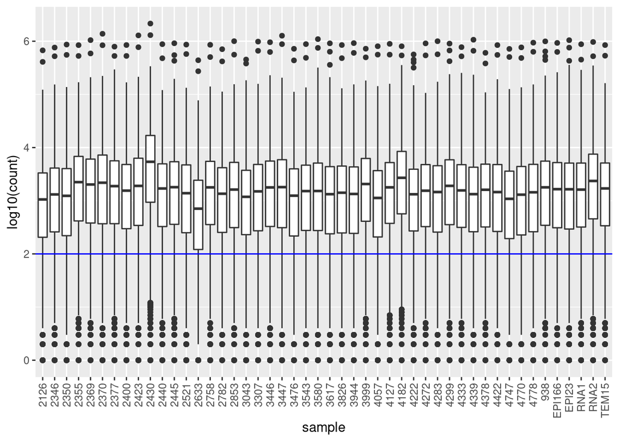

Second, sample that presents a lower or higher coverage might be considered as outlier since C-score robustness is dependent on the coverage. **Here is a Relative Log Coverage plot given the variation of the end read counts to the serie/sample (?) median for each individual sample.** The blue lines give median +/- 2mad variation. Median outside the blue lines identifies putative outlier sample.

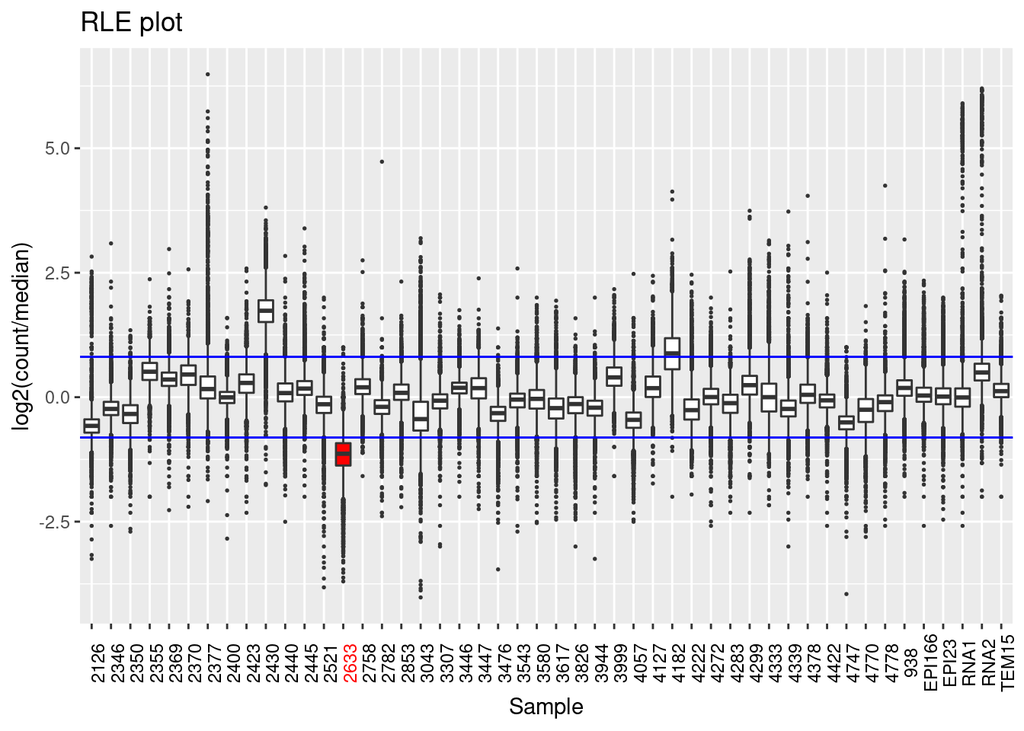